# 1. DataPreparation

Gonzalo Albaladejo-Robles

2025-06-06

- Set up the environment

```r
rm(list=ls())
gc()
#.rs.restartR()
options(java.parameters = "-Xmx5g") # increase the memory space for jave before loading any package
options("rgdal_show_exportToProj4_warnings"="none") # Silence packages updates warnings

setwd(dirname(rstudioapi::getSourceEditorContext()$path)) # Set the working directory to the directory in which the code is stored
td<-tempdir()
dir.create(td,showWarnings = FALSE)
```

### 1. Data collection

We are going to use the `Download_gbif` function to get georeference presence records from the Global Biodiversity Information Facility ([**GBIF**](https://www.gbif.org/)). **GBIF** is made off multiple data sets, from scientific literature, to goverment assesments and monitoring programs, citicence science, and historical records. Since datasets are very heterogeous and cover a several years, they also contain different taxonomies. Therefore, before our query we need to perform a taxonomic macthing to retrieve all the known, or at least recorded, synonyms for the species. This process is carried out by the `retrive_syns` function. This function gave us the option to search the Integrated Taxonomic Information System ([**ITIS**](https://www.itis.gov/)) and [**IUCN RedList**](https://www.iucnredlist.org/), and optionally also **GBIF**, repositories and extract the list of synonyms and upstream taxonomic information (up to the level of Phylum) for the species or list of target species.

Both the taxonomic revision and data gathering from **GBIF** can be executed individually by using the individual functions with their parameters or automatically using the `Spatial_spp` function. This function allow users to retrieve the taxonomic information and spatial records for a given specie, using only 5 parameters from which only two are mandatory (`sci_sp` and `key.IUCN`).

1. Configure some project parameters

```r
crs_p <- "EPSG:4326"
sf_use_s2(F)
```

```
## Spherical geometry (s2) switched off
```

2. Download the spatial and taxonomic information for the species By default `Spatial_spp` would create a `Data/sp_points` folder in the user working directory to store the downloaded spatial. The taxonomic information is store in the `Data/Sp_info` folder, also created by default by the function. Along the different scripts of this repostitory we are going to build multiple SDM for the red the red-necked wallaby (*Macropus rufogriseus* or *Notamacropus rufogriseus*, depending on which taxonomy we are using).

Get some basic spatial information for the study area and species range. For the species range we are going to use the spatial information from the [IUCN RedList](https://www.iucnredlist.org/resources/spatial-data-download#:~:text=The%20IUCN%20Red%20List%20of%20Threatened%20Species%E2%84%A2%20contains%20global,groups%20and%20selected%20freshwater%20groups.).

```r
# Get the general sampling area
country_border <- geodata::gadm(country="aus",path=td,level=0)
country_border <- country_border %>% st_as_sf() %>% st_make_valid() %>% st_transform(crs = crs_p)

# World polygon
terra_border <- geodata::world(resolution=3,level=0,path=td)
terra_border <- terra_border %>% st_as_sf() %>% st_make_valid() %>% st_transform(crs = crs_p)

# Get the IUCN range data (this has been pre-downloaded and resize to fit GitHub requirements)
rX <- st_read("./Data/IUCN_sp_Range" %>% list.files(pattern = ".shp",full.names = TRUE)) %>% st_transform(crs = crs_p)
```

Download the spatial records and taxonomy of the species We need to include a IUCN RedList API key for the taxonomic search and access the species general information in the IUCN servers. An API key can be obtain [here](https://api.iucnredlist.org/).

[output not shown]

```
##
## Retrieving data for taxon 'Macropus rufogriseus'
```

```
## ══  1 queries  ═══════════════
```

```
##
## Retrieving data for taxon 'Macropus rufogriseus'
```

```
## ✔  Found:  Macropus rufogriseus
## ══  Results  ═════════════════
##
## • Total: 1
## • Found: 1
## • Not Found: 0
## ══  1 queries  ═══════════════
```

```
##
## Retrieving data for taxon 'Notamacropus rufogriseus'
```

```
## ✔  Found:  Notamacropus rufogriseus
## ══  Results  ═════════════════
##
## • Total: 1
## • Found: 1
## • Not Found: 0
## [1] "year=1"
## [1] "1-1"
## [1] "1-2"
## [1] "1-3"
## [1] "1-4"
## [1] "1-5"
## [1] "1-6"
## [1] "1-7"
## [1] "1-8"
```

[output cut: 136 more lines]

- Check species tax

```r
# Print the taxonomic information
print(tax_sp)
```

```
##                Or_name IUCN_Present IUCN_id                IUCN_name
## 1 Macropus rufogriseus          Yes   40566 Notamacropus rufogriseus
##   IUCN_Category IUCN_N_syn
## 1         LR/lc          3
##                                                        IUCN_syn IUCN_Phylum
## 1 Macropus ruficollis;Wallabia rufogriseus;Macropus rufogriseus    CHORDATA
##   IUCN_Class    IUCN_Order  IUCN_Family ITIS_Present ITIS_is_valid ITIS_id
## 1   MAMMALIA DIPROTODONTIA MACROPODIDAE         TRUE         FALSE 1255582
##                  ITIS_name ITIS_Phylum ITIS_N_syn
## 1 Notamacropus rufogriseus    CHORDATA          2
##                                    ITIS_syn ITIS_Class    ITIS_Order
## 1 Macropus rufogriseus;Kangurus rufogriseus   MAMMALIA DIPROTODONTIA
##    ITIS_Family
## 1 MACROPODIDAE
```

The algorithm was able to identified 3 different synonyms. Therefore, for *Macropus rufogriseus* the algorithm would check the **GBIF** servers for spatial data related with the species and its associated synonyms (**) and group all the observations under a single species binomial designation (the original name provided to `Spatial_spp`).

3. Load and clean the species spatial records

Since **GBIF** points came from different sources and sampling methods we need to “clean” the data set in order to preserve only the spatial points with a high level spatial congruence. For this we are going to use the `Prepare_points` function which is a wrapper around the `CoordinateCleaner` that also allows some extra spatial filtering using user defined spatial information such as species ranges or study area boundaries.

```r
# Load the points
sp_points <- list.files("./Data/sp_points",pattern = "Macropus rufogriseus.csv",full.names = TRUE) %>% read.csv()

# Clean the spatial points using the CoordinateCleaner
sp_clean <- Prepare_points(points_sp = sp_points,range_sp = rX)
```

```
## Testing coordinate validity
```

```
## Flagged 0 records.
```

```
## Testing equal lat/lon
```

```
## Flagged 0 records.
```

```
## Testing zero coordinates
```

```
## Flagged 0 records.
```

```
## Testing country capitals
```

```
## Flagged 78 records.
```

```
## Testing country centroids
```

```
## Flagged 0 records.
```

```
## Testing sea coordinates
```

```
## Flagged 416 records.
```

```
## Testing geographic outliers
```

```
## Flagged 57 records.
```

```
## Testing GBIF headquarters, flagging records around Copenhagen
```

```
## Flagged 0 records.
```

```
## Testing biodiversity institutions
```

```
## Flagged 0 records.
```

```
## Flagged 551 of 23253 records, EQ = 0.02.
```

```
## dist is assumed to be in decimal degrees (arc_degrees).
```

```
## although coordinates are longitude/latitude, st_union assumes that they are
## planar
```

```
## although coordinates are longitude/latitude, st_intersects assumes that they
## are planar
## although coordinates are longitude/latitude, st_intersects assumes that they
## are planar
```

The original **GBIF** data had 23253 observations whereas the clean data set has 21361. From this final set of observations 10022 belong to unique geographical locations or points. We are going to save the clean records for the analysis.

- Export the Clean Data

```r
# Export the processed points
clean_dir <- paste(getwd(),"./Data/sp_points/Process",sep="/")
clean_dir %>% dir.create(recursive=T,showWarnings = F)

sp_clean %>% write.csv(paste(clean_dir,"Macropus rufogriseus_C.csv",sep="/"))

# Load the data from the folder
sp_clean <- clean_dir %>% list.files(pattern = "Macropus rufogriseus_C.csv",full.names = T) %>% read.csv()
```

4. Display the species spatial information

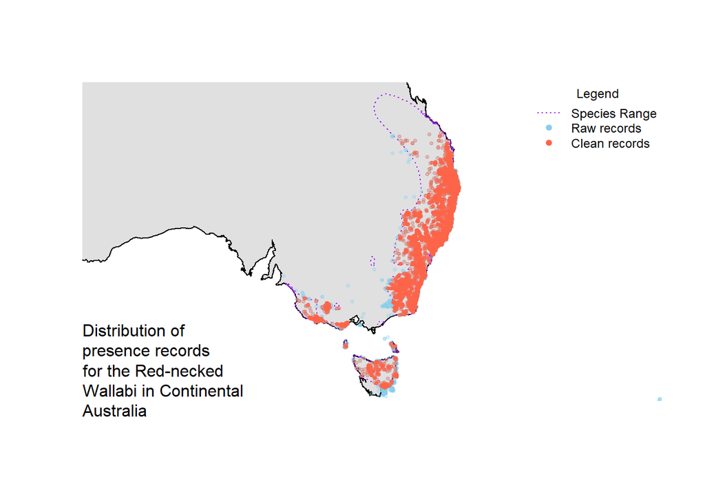

```r
# Transform the points information into spatial data
o_points <- sp_points %>% st_as_sf(coords=c("decimalLongitude","decimalLatitude"),crs="EPSG:4326")
c_points <- sp_clean %>% st_as_sf(coords=c("decimalLongitude","decimalLatitude"),crs="EPSG:4326")

# Display the spatial information
# Prepare the general geometry
AUS_pols <- country_border %>% st_cast("POLYGON")
AUS_pols <- AUS_pols[AUS_pols %>% st_intersects(st_union(c_points),sparse=F),]

# General map (country + species range)
  rX %>% st_geometry() %>% plot(col="purple" %>% adjustcolor(alpha.f = 0.5),mar=c(0,0,0,0))
  AUS_pols %>% st_geometry() %>% plot(mar=c(0,0,0,0),col="grey88",add=T)
  lines(rX,col="purple",lwd=1.2,lty=3)

# Original records
  o_points %>% st_geometry() %>% plot(add=T,col="skyblue" %>% adjustcolor(alpha.f = 0.25),pch=19,cex=0.5)

# Clean up records
  c_points %>% st_geometry() %>% plot(add=T,col="tomato" %>% adjustcolor(alpha.f = 0.25),pch=19,cex=0.5)

  mtext(side=1,adj=0,"Distribution of\npresence records\nfor the Red-necked\nWallabi in Continental\nAustralia")
  legend("topright",title="Legend",legend=c("Species Range","Raw records","Clean records"), pch=c(NA,19,19),lty=c(3,NA,NA),lwd=1.2,cex=0.75,col=c("purple","skyblue","tomato"),bty="n")
```

5. Preparing background and pseudo-absence data

Different SDM methods require distinct records to compare against the presence data. Presence only methods call these counter factual observations **background** records. The objective of the background data is to extract a representation of the environmental information present within our study are or species range. In the case of the presence absence SDM methods, they rely on the differences between areas in which the species have been recorded and others in which the species has not been detected despite monitoring. Absence data is hard to obtain, unless we have total control on our target species survey/monitoring. For most species only presence data is available. Due to this presence absence methods usually rely on **pseudo-absence** records. This records can be created following some rules to mimic the distribution of “true” absences.

- Generating background information using the `backgroundPOINTS` function. This function is part of the **AutoMaxent** repository so be sure to run the `0. Prepare_environment.R` script before this code.

```r
# A random distribution of points
r_bk <- backgroundPOINTS(presence=c_points, # Distribution points of the species
                 background_n = 10000, # Number of background points
                 TrainTest = 1, # Proportion of data used for the testing and training of the models
                 range_samp = AUS_pols, # Range information of species
                 weights.p="Random" # "Random","BwData","BwData_inv"
                 )$Train
```

```
## dist is assumed to be in decimal degrees (arc_degrees).
```

```
## although coordinates are longitude/latitude, st_union assumes that they are
## planar
```

[output not shown]

```r
# Base on the density of distribution points
r_bw <- backgroundPOINTS(presence=c_points, # Distribution points of the species
                 background_n = 10000, # Number of background points
                 TrainTest = 1, # Proportion of data used for the testing and training of the models
                 range_samp = AUS_pols, # Range information of species
                 weights.p="BwData")$Train
```

```
## dist is assumed to be in decimal degrees (arc_degrees).
```

```
## although coordinates are longitude/latitude, st_union assumes that they are
## planar
```

```
## [1] "density of observations, between 0-1, returned!"
```

```r
# Base on the density of distribution points
r_binv <- backgroundPOINTS(presence=c_points, # Distribution points of the species
                 background_n = 10000, # Number of background points
                 TrainTest = 1, # Proportion of data used for the testing and training of the models
                 range_samp = AUS_pols, # Range information of species
                 weights.p="BwData_inv")$Train
```

```
## dist is assumed to be in decimal degrees (arc_degrees).
## although coordinates are longitude/latitude, st_union assumes that they are
## planar
```

```
## [1] "Inverse density of observations, between 0-1, returned!"
```

```r
# Store the points
background.p <- list(Random=r_bk,Weighted=r_bw,InvWeigthed=r_binv)
```

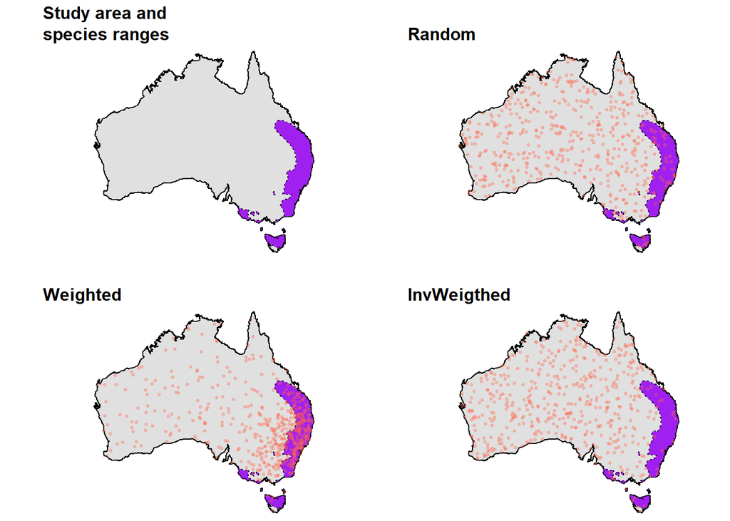

Background point distribution

- Generating pseudo-absence information using the `backgroundPOINTS` function and a custom polygon

```r
# Configure the sampling area to produce the pseudo-absence data
p.exclusion <- c_points %>% st_buffer(dist=0.5) %>% st_union() # Add a buffer around the points and fuse the geometries to create an exclusion area
```

```
## dist is assumed to be in decimal degrees (arc_degrees).
```

```
## although coordinates are longitude/latitude, st_union assumes that they are
## planar
```

```r
study.area <- st_difference(AUS_pols,p.exclusion) %>% st_geometry()
```

```
## although coordinates are longitude/latitude, st_difference assumes that they
## are planar
```

```r
# Create the psudo-absence data
# a. Random records
p.random <- backgroundPOINTS(presence=c_points, # Distribution points of the species
                 background_n = 10000, # Number of background points
                 TrainTest = 1, # Proportion of data used for the testing and training of the models
                 range_samp = study.area, # Range information of species
                 weights.p="Random")$Train
```

```
## dist is assumed to be in decimal degrees (arc_degrees).
## although coordinates are longitude/latitude, st_union assumes that they are
## planar
```

```
## although coordinates are longitude/latitude, st_intersects assumes that they
## are planar
## although coordinates are longitude/latitude, st_intersects assumes that they
## are planar
## although coordinates are longitude/latitude, st_intersects assumes that they
## are planar
## although coordinates are longitude/latitude, st_intersects assumes that they
## are planar
```

```
## although coordinates are longitude/latitude, st_intersects assumes that they
## are planar
```

```r
# b. Presence weigthing
p.bw <- backgroundPOINTS(presence=c_points, # Distribution points of the species
                 background_n = 10000, # Number of background points
                 TrainTest = 1, # Proportion of data used for the testing and training of the models
                 range_samp = study.area, # Range information of species
                 weights.p="BwData")$Train
```

```
## dist is assumed to be in decimal degrees (arc_degrees).
```

```
## although coordinates are longitude/latitude, st_union assumes that they are
## planar
```

```
## [1] "density of observations, between 0-1, returned!"
```

```r
# c. Random records
p_binv <- backgroundPOINTS(presence=c_points, # Distribution points of the species
                 background_n = 10000, # Number of background points
                 TrainTest = 1, # Proportion of data used for the testing and training of the models
                 range_samp = study.area, # Range information of species
                 weights.p="BwData_inv")$Train
```

```
## dist is assumed to be in decimal degrees (arc_degrees).
## although coordinates are longitude/latitude, st_union assumes that they are
## planar
```

```
## [1] "Inverse density of observations, between 0-1, returned!"
```

```r
# Store the points
pseudo.p <- list(Random=p.random,Weighted=p.bw,InvWeigthed=p_binv)
```

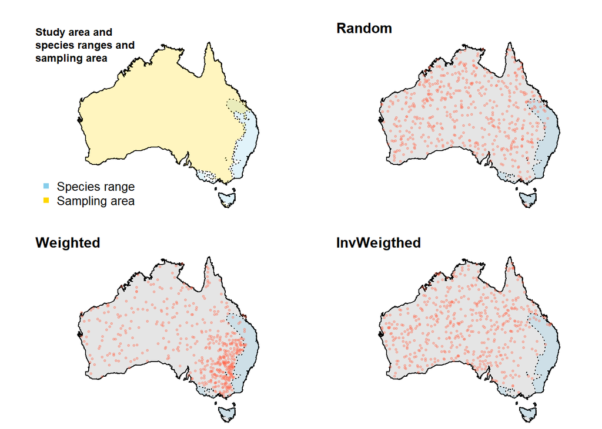

- Export the point data

```r
# We are going to use the same sp_info folder
p.route <- "./Data/sp_points/Process/Contrast_points" ; p.route %>% dir.create(showWarnings = FALSE, recursive = T)

st_write(study.area,paste(p.route,"Contrast_geopackage.gpkg",sep="/"),layer="Sampling_area_PseudoAb",append=F)
```

```
## Deleting layer `Sampling_area_PseudoAb' using driver `GPKG'
## Writing layer `Sampling_area_PseudoAb' to data source
##   `./Data/sp_points/Process/Contrast_points/Contrast_geopackage.gpkg' using driver `GPKG'
## Writing 2 features with 0 fields and geometry type Multi Polygon.
```

```r
# Export the pseudo-absence and background data to a common geopackage
# Pseudo-absence
for(i in names(pseudo.p)){
  st_write(pseudo.p[[i]],paste(p.route,"Contrast_geopackage.gpkg",sep="/"),layer=paste0("Pseudo_",i),append=F)
}
```

```
## Deleting layer `Pseudo_Random' using driver `GPKG'
## Writing layer `Pseudo_Random' to data source
##   `./Data/sp_points/Process/Contrast_points/Contrast_geopackage.gpkg' using driver `GPKG'
## Writing 10000 features with 0 fields and geometry type Point.
## Deleting layer `Pseudo_Weighted' using driver `GPKG'
## Writing layer `Pseudo_Weighted' to data source
##   `./Data/sp_points/Process/Contrast_points/Contrast_geopackage.gpkg' using driver `GPKG'
## Writing 8000 features with 0 fields and geometry type Point.
## Deleting layer `Pseudo_InvWeigthed' using driver `GPKG'
## Writing layer `Pseudo_InvWeigthed' to data source
##   `./Data/sp_points/Process/Contrast_points/Contrast_geopackage.gpkg' using driver `GPKG'
## Writing 8000 features with 0 fields and geometry type Point.
```

```r
# Background records
for(i in names(background.p)){
  st_write(background.p[[i]],paste(p.route,"Contrast_geopackage.gpkg",sep="/"),layer=paste0("Background_",i),append=F)
}
```

```
## Deleting layer `Background_Random' using driver `GPKG'
## Writing layer `Background_Random' to data source
##   `./Data/sp_points/Process/Contrast_points/Contrast_geopackage.gpkg' using driver `GPKG'
## Writing 10000 features with 0 fields and geometry type Point.
## Deleting layer `Background_Weighted' using driver `GPKG'
## Writing layer `Background_Weighted' to data source
##   `./Data/sp_points/Process/Contrast_points/Contrast_geopackage.gpkg' using driver `GPKG'
## Writing 8000 features with 0 fields and geometry type Point.
## Deleting layer `Background_InvWeigthed' using driver `GPKG'
## Writing layer `Background_InvWeigthed' to data source
##   `./Data/sp_points/Process/Contrast_points/Contrast_geopackage.gpkg' using driver `GPKG'
## Writing 8000 features with 0 fields and geometry type Point.
```

## 2. Download environmental data—-

The selection and distribution of environmental gradients is going to have a direct effect on SDM fit, performance, and ecological relevance. In this example we are going to model the potential distribution of the red-necked Wallabi with a few additions to approach the specis realize niche. Therefore we are going to download climatic data along with some land-cover information.

1. Download climatic data from (WorldClim)

```r
# We want this to be relatively fast, so lets take the 10 sqr km resolution and limit the data gathering to the UK and Australia
bio_clim <- "./Data/Environmental variables/BioClim" ; dir.create(bio_clim,recursive = TRUE,showWarnings = FALSE)

lapply(c("AUS","GBR"), function(x)
  geodata::worldclim_country(country = x,res=0.5,path=bio_clim,var="bio"))
```

```
## [[1]]
## class       : SpatRaster
## dimensions  : 5580, 5640, 19  (nrow, ncol, nlyr)
## resolution  : 0.008333333, 0.008333333  (x, y)
## extent      : 112.5, 159.5, -55.5, -9  (xmin, xmax, ymin, ymax)
## coord. ref. : lon/lat WGS 84 (EPSG:4326)
## source      : AUS_wc2.1_30s_bio.tif
## names       : wc2.1~bio_1, wc2.1~bio_2, wc2.1~bio_3, wc2.1~bio_4, wc2.1~bio_5, wc2.1~bio_6, ...
## min values  :    3.445833,    1.599999,    21.05263,    36.13946,         7.6,        -7.7, ...
## max values  :   29.408333,   17.525000,    86.14720,   684.30566,        42.6,        24.7, ...
##
## [[2]]
## class       : SpatRaster
## dimensions  : 1500, 1920, 19  (nrow, ncol, nlyr)
## resolution  : 0.008333333, 0.008333333  (x, y)
## extent      : -14, 2, 49.5, 62  (xmin, xmax, ymin, ymax)
## coord. ref. : lon/lat WGS 84 (EPSG:4326)
## source      : GBR_wc2.1_30s_bio.tif
## names       : wc2.1~bio_1, wc2.1~bio_2, wc2.1~bio_3, wc2.1~bio_4, wc2.1~bio_5, wc2.1~bio_6, ...
## min values  :    2.079167,    2.150000,    25.94086,    197.8636,         9.8,        -4.6, ...
## max values  :   12.320833,    8.766666,    43.34319,    533.8559,        23.5,         7.6, ...
```

2. Download some land cover data form the European Space Agency land_use harmonization project (LH1)[https://climate.esa.int/en/projects/land-cover/data/]

We are going to focus on a limited set of (plant functional types)[https://essd.copernicus.org/articles/15/1465/2023/essd-15-1465-2023-discussion.html] in order to simplify the process. Ideally, for an exaustive SDM model, we would conduct our variable selection process base on the ecology of the species and the spatio temporal requirements of our study. This takes some more time since the data is high-res.

```r
# 3.2 Prepare some land-use information (in this case we are going to use the land-use from the Land-Use Harmonization project, LH1)----
Lu_route<-"./Data/Environmental variables/Land_use"
dir.create(Lu_route,recursive = TRUE,showWarnings = FALSE)

Lu_vars<-c("trees", "grassland", "shrubs", "cropland", "bare")
lapply(Lu_vars,function(x) geodata::landcover(var=x,path=Lu_route))
```

```
## [[1]]
## class       : SpatRaster
## dimensions  : 17280, 43200, 1  (nrow, ncol, nlyr)
## resolution  : 0.008333333, 0.008333333  (x, y)
## extent      : -180, 180, -60, 84  (xmin, xmax, ymin, ymax)
## coord. ref. : lon/lat WGS 84 (EPSG:4326)
## source      : WorldCover_trees_30s.tif
## name        : trees
## min value   :     0
## max value   :     1
##
## [[2]]
## class       : SpatRaster
## dimensions  : 17280, 43200, 1  (nrow, ncol, nlyr)
## resolution  : 0.008333333, 0.008333333  (x, y)
## extent      : -180, 180, -60, 84  (xmin, xmax, ymin, ymax)
## coord. ref. : lon/lat WGS 84 (EPSG:4326)
## source      : WorldCover_grassland_30s.tif
## name        : grassland
## min value   :         0
## max value   :         1
##
## [[3]]
## class       : SpatRaster
## dimensions  : 17280, 43200, 1  (nrow, ncol, nlyr)
## resolution  : 0.008333333, 0.008333333  (x, y)
## extent      : -180, 180, -60, 84  (xmin, xmax, ymin, ymax)
## coord. ref. : lon/lat WGS 84 (EPSG:4326)
## source      : WorldCover_shrubs_30s.tif
## name        : shrubs
## min value   :      0
## max value   :      1
##
## [[4]]
## class       : SpatRaster
## dimensions  : 17280, 43200, 1  (nrow, ncol, nlyr)
## resolution  : 0.008333333, 0.008333333  (x, y)
## extent      : -180, 180, -60, 84  (xmin, xmax, ymin, ymax)
## coord. ref. : lon/lat WGS 84 (EPSG:4326)
## source      : WorldCover_cropland_30s.tif
## name        : cropland
## min value   :        0
## max value   :        1
##
## [[5]]
## class       : SpatRaster
## dimensions  : 17280, 43200, 1  (nrow, ncol, nlyr)
## resolution  : 0.008333333, 0.008333333  (x, y)
## extent      : -180, 180, -60, 84  (xmin, xmax, ymin, ymax)
## coord. ref. : lon/lat WGS 84 (EPSG:4326)
## source      : WorldCover_bare_30s.tif
## name        : bare
## min value   :    0
## max value   :    1
```

3. Check the environmental information

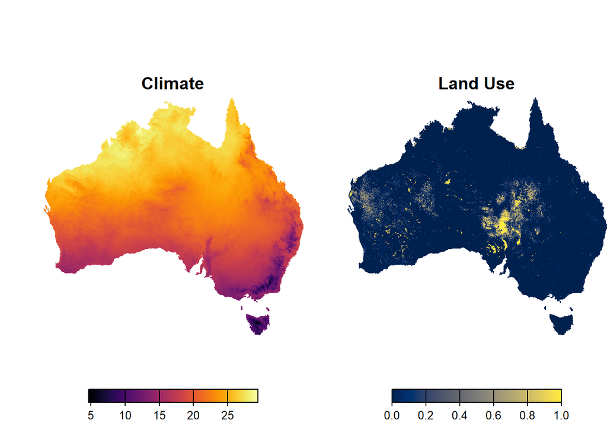

```r
# Load the raster data and check its distribution
# Bioclim
BioClim_routes <-"./Data/Environmental variables/BioClim" %>% list.files(pattern=".tif$",recursive=T,full.names = TRUE)

# Land-use
ESA_lh_routes <- "./Data/Environmental variables/Land_use" %>% list.files(pattern=".tif$",recursive=T,full.names = TRUE)

Clim<- BioClim_routes[1] %>% rast()
Lu <- ESA_lh_routes[1] %>% rast()

par(mfrow=c(1,2))
Clim[[1]] %>% crop(AUS_pols %>% vect())  %>% mask(AUS_pols %>% vect()) %>% plot(col=viridis::inferno(250),mar=c(0,2.5,0,0),axes=F,plg=list(x="bottom",size=0.65),main="Climate")

Lu[[1]] %>% crop(AUS_pols %>% vect()) %>% mask(AUS_pols %>% vect()) %>% plot(col=viridis::cividis(250),mar=c(0,2.5,0,0),axes=F,plg=list(x="bottom",size=0.65),main="Land Use")
```

- Layer spatial parameters

```r
# Layer parameters
Lu[[1]] %>% crs() ; Lu[[1]] %>% ext() ; Lu[[1]] %>% res()
```

```
## [1] "GEOGCRS[\"WGS 84\",\n    ENSEMBLE[\"World Geodetic System 1984 ensemble\",\n        MEMBER[\"World Geodetic System 1984 (Transit)\"],\n        MEMBER[\"World Geodetic System 1984 (G730)\"],\n        MEMBER[\"World Geodetic System 1984 (G873)\"],\n        MEMBER[\"World Geodetic System 1984 (…
```

```
## SpatExtent : -180, 179.99999999999, -59.999999999996, 84 (xmin, xmax, ymin, ymax)
```

```
## [1] 0.008333333 0.008333333
```

```r
Clim[[1]] %>% crs() ; Clim[[1]] %>% ext() ; Clim[[1]] %>% res()
```

```
## [1] "GEOGCRS[\"WGS 84\",\n    ENSEMBLE[\"World Geodetic System 1984 ensemble\",\n        MEMBER[\"World Geodetic System 1984 (Transit)\"],\n        MEMBER[\"World Geodetic System 1984 (G730)\"],\n        MEMBER[\"World Geodetic System 1984 (G873)\"],\n        MEMBER[\"World Geodetic System 1984 (…
```

```
## SpatExtent : 112.5, 159.5, -55.5, -9 (xmin, xmax, ymin, ymax)
```

```
## [1] 0.008333333 0.008333333
```

```r
# Harmonize all the raster layer using the most common paramters
env_vars_AUS <- c(BioClim_routes[1],ESA_lh_routes) # We need to gather the
env_vars_GBR <- c(BioClim_routes[2],ESA_lh_routes) # We need to gather the

# Harmonize the data
resample.rast(x=NULL,y=env_vars_AUS,results.r="./Data/Environmental variables/Processed/AUS") # adapt and export the data
```

```
## [1] "Missing key components to build the reference raster, sampling the layers to select the best fit!"
## |---------|---------|---------|---------|=========================================                                          [1] "SUCCESS!!"
## [1] "SUCCESS!!"
## [1] "SUCCESS!!"
## [1] "SUCCESS!!"
## [1] "SUCCESS!!"
## [1] "SUCCESS!!"
## [1] "ALL DONE!"
```

```
## $layers
## [1] "bare"            "cropland"        "grassland"       "shrubs"
## [5] "trees"           "wc2.1_30s_bio_1"
##
## $parameters
## $parameters$crs
## [1] "GEOGCRS[\"WGS 84\",\n    ENSEMBLE[\"World Geodetic System 1984 ensemble\",\n        MEMBER[\"World Geodetic System 1984 (Transit)\"],\n        MEMBER[\"World Geodetic System 1984 (G730)\"],\n        MEMBER[\"World Geodetic System 1984 (G873)\"],\n        MEMBER[\"World Geodetic System 1984 (…
##
## $parameters$extent
##  xmin  ymin  xmax  ymax
## 112.5 -55.5 159.5  -9.0
##
## $parameters$resolution
## [1] 0.008333333
```

```r
resample.rast(x=NULL,y=env_vars_GBR,results.r="./Data/Environmental variables/Processed/GBR") # adapt and export the data
```

```
## [1] "Missing key components to build the reference raster, sampling the layers to select the best fit!"
## [1] "SUCCESS!!"
## [1] "SUCCESS!!"
## [1] "SUCCESS!!"
## [1] "SUCCESS!!"
## [1] "SUCCESS!!"
## [1] "SUCCESS!!"
## [1] "ALL DONE!"
```

```
## $layers
## [1] "bare"            "cropland"        "grassland"       "shrubs"
## [5] "trees"           "wc2.1_30s_bio_1"
##
## $parameters
## $parameters$crs
## [1] "GEOGCRS[\"WGS 84\",\n    ENSEMBLE[\"World Geodetic System 1984 ensemble\",\n        MEMBER[\"World Geodetic System 1984 (Transit)\"],\n        MEMBER[\"World Geodetic System 1984 (G730)\"],\n        MEMBER[\"World Geodetic System 1984 (G873)\"],\n        MEMBER[\"World Geodetic System 1984 (…
##
## $parameters$extent
##  xmin  ymin  xmax  ymax
## -14.0  49.5   2.0  62.0
##
## $parameters$resolution
## [1] 0.008333333
```

5. Display the spatial information

   Bioclimatic data